# Classification with caret in R

# 1 1 R - Preliminaries

## 1.1 1.1 Load data and set options

```r
library(caret)
library(tidyverse)
library(corrplot)
library(xtable)
library(kableExtra)
data = read.csv('data/loans.csv')
data_dictionary = read.csv('data/loans_dictionary.csv')
# use kable to print a nice html table
select(data_dictionary,c('name','description')) %>%
  kable %>%
  kable_styling()
```

| name | description |
| --- | --- |
| loan_status | Loan status 0 = charged off, 1 = paid in full |
| total_pymnt | Total amount repaid |
| loan_amnt | Amount of loan |
| term | The number of payments on the loan. Values are in months and can be either 36 or 60. |
| grade | Grade of loan 1 through 7, 1 is for best loans |
| emp_length | Employment length in years. Possible values are between 0 and 10 where 0 means less than one year and 10 means ten or more years. |
| home_ownership | The home ownership status provided by the borrower during registration or obtained from the credit report. Our values are: RENT, OWN, MORTGAGE, OTHER |
| annual_inc | The self-reported annual income provided by the borrower during registration. |
| purpose | A category provided by the borrower for the loan request. |
| addr_state | Region of US of borrower. N = |
| dti | A ratio calculated using the borrower’s total monthly debt payments on the total debt obligations, excluding mortgage and the requested LC loan, divided by the borrower’s self-reported monthly income. |
| delinq_2yrs | The number of 30+ days past-due incidences of delinquency in the borrower’s credit file for the past 2 years |
| earliest_cr_line | Days since first credit line established |
| inq_last_6mths | The number of inquiries in past 6 months (excluding auto and mortgage inquiries) |
| open_acc | The number of open credit lines in the borrower’s credit file. |
| pub_rec | Number of derogatory public records |
| revol_bal | Total credit revolving balance |
| revol_util | Revolving line utilization rate, or the amount of credit the borrower is using relative to all available revolving credit. |
| last_credit_pull_d | Days since last credit check |
| pub_rec_bankruptcies | Number of public record bankruptcies |

## 1.2 1.2 Define target and feature variables

The target variable will be **loan_status** while all the other variables are features. **loan_status** is numerical (0’s and 1’s), but should be a factor variable for classification in R. Note, the **total_pymnt** column contains information about whether or not the loan was paid and needs to be removed.

```r
data$loan_status = as.factor(data$loan_status)
data = select(data,-"total_pymnt")
```

# 2 Training a Classification Model

Use logistic regression to predict loan defaults.

## 2.1 2.1 Split into test and training sets

Use **createDataPartition** from the `caret` package.

```r
set.seed(100) # for reproducibility
inTrain = createDataPartition(y = data$loan_status, p = .8, list = FALSE)
training = slice( data, inTrain ) # slice from dplyr for subsetting
testing = slice( data, -inTrain)
```

## 2.2 2.2 Simple fit and error estimate

For a simple model that fits all the training data we can use either glm() or the train() function from caret.

```r
f = as.formula("loan_status~.")
logisticRegr = glm(f, family = "binomial", data = training )
# alternately the two lines below could be run
#logisticRegr = train(form = f, data = training, method="glm",
#                      family = "binomial",trControl = trainControl(method="none"))
```

Make predictions using the features in the testing data.

```r
y_pred_prob = predict(logisticRegr, testing, type="response")
y_pred = as.factor(ifelse( y_pred_prob > .5, 1, 0))
confusionMatrix( y_pred, testing$loan_status )
```

```
## Confusion Matrix and Statistics
##
##           Reference
## Prediction    0    1
##          0   20   35
##          1 1041 6494
##
##                Accuracy : 0.8582
##                  95% CI : (0.8502, 0.866)
##     No Information Rate : 0.8602
##     P-Value [Acc > NIR] : 0.6971
##
##                   Kappa : 0.0224
##  Mcnemar's Test P-Value : <2e-16
##
##             Sensitivity : 0.018850
##             Specificity : 0.994639
##          Pos Pred Value : 0.363636
##          Neg Pred Value : 0.861845
##              Prevalence : 0.139789
##          Detection Rate : 0.002635
##    Detection Prevalence : 0.007246
##       Balanced Accuracy : 0.506745
##
##        'Positive' Class : 0
##
```

## 2.3 2.3 Other Error Metrics

Plot the ROC curve and display AUC.

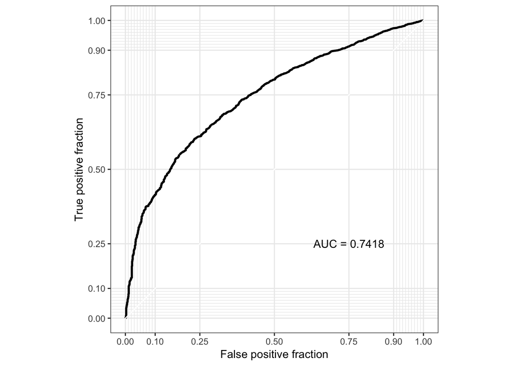

```r
library(plotROC)
rocdata <- data.frame(D = as.integer(testing$loan_status)-1,
                      M = y_pred_prob,
                      Z = ifelse(testing$loan_status=="0","F","S"))
g <- ggplot(rocdata, aes(m = M, d = D)) +
  geom_roc(n.cuts=0) +
  coord_equal() +
  style_roc()
g + annotate("text", x=0.75, y=0.25, label=paste("AUC =", round((calc_auc(g))$AUC, 4)))
```

## 2.4 2.4 Model Selection Using Cross Validation

In `caret` the method `glmnet` can be used to do logistic regression with regulatization in the form of a penalty term that corresponds to ridge or lasso regression. Ridge regression is similar to LogisticRegression in sklearn. The search grid used for the regularization parameter $\lambda$ is the result of a few iterations of searching in larger grids and refining the range of values. The glmnet method has trouble with using “0” and “1” for loan status so we replace those with “F” and “S”

```r
levels(training$loan_status) = c("F","S")
set.seed(100) # for reproducibility
tuneGrid <- expand.grid(alpha = 0:1, lambda = seq(0.0001, .001, length = 10))
trControl = trainControl(method="cv",
                         number=5,
                         classProbs = TRUE,
                         summaryFunction = twoClassSummary)
best_model <- train( loan_status ~ ., data = training,
                method = "glmnet",
                tuneGrid = tuneGrid,
                trControl = trControl,
                metric = "ROC",
                preProc = c("center","scale"))
best_model
```

```
## glmnet
##
## 30363 samples
##    18 predictor
##     2 classes: 'F', 'S'
##
## Pre-processing: centered (35), scaled (35)
## Resampling: Cross-Validated (5 fold)
## Summary of sample sizes: 24290, 24290, 24290, 24292, 24290
## Resampling results across tuning parameters:
##
##   alpha  lambda  ROC        Sens        Spec
##   0      1e-04   0.7315977  0.01672862  0.9969371
##   0      2e-04   0.7315977  0.01672862  0.9969371
##   0      3e-04   0.7315977  0.01672862  0.9969371
##   0      4e-04   0.7315977  0.01672862  0.9969371
##   0      5e-04   0.7315977  0.01672862  0.9969371
##   0      6e-04   0.7315977  0.01672862  0.9969371
##   0      7e-04   0.7315977  0.01672862  0.9969371
##   0      8e-04   0.7315977  0.01672862  0.9969371
##   0      9e-04   0.7315977  0.01672862  0.9969371
##   0      1e-03   0.7315977  0.01672862  0.9969371
##   1      1e-04   0.7318532  0.02214814  0.9957502
##   1      2e-04   0.7318532  0.02214814  0.9957502
##   1      3e-04   0.7318588  0.02214814  0.9957502
##   1      4e-04   0.7318692  0.02167672  0.9958268
##   1      5e-04   0.7318282  0.02096973  0.9958651
##   1      6e-04   0.7317881  0.02049859  0.9959799
##   1      7e-04   0.7317396  0.01979160  0.9960948
##   1      8e-04   0.7316943  0.01932018  0.9962479
##   1      9e-04   0.7316440  0.01884903  0.9964011
##   1      1e-03   0.7315936  0.01837761  0.9964394
##
## ROC was used to select the optimal model using the largest value.
## The final values used for the model were alpha = 1 and lambda = 4e-04.
```

The best model was produced using lasso regression ($\alpha = 1$) with regularization parameter $\lambda = 0.0004$.

```r
y_pred_prob = predict(best_model, testing, type="prob")[,2]
y_pred = as.factor(ifelse( y_pred_prob > .5, 1, 0))
confusionMatrix( y_pred, testing$loan_status )
```

```
## Confusion Matrix and Statistics
##
##           Reference
## Prediction    0    1
##          0   19   33
##          1 1042 6496
##
##                Accuracy : 0.8584
##                  95% CI : (0.8503, 0.8661)
##     No Information Rate : 0.8602
##     P-Value [Acc > NIR] : 0.6855
##
##                   Kappa : 0.0214
##  Mcnemar's Test P-Value : <2e-16
##
##             Sensitivity : 0.017908
##             Specificity : 0.994946
##          Pos Pred Value : 0.365385
##          Neg Pred Value : 0.861767
##              Prevalence : 0.139789
##          Detection Rate : 0.002503
##    Detection Prevalence : 0.006851
##       Balanced Accuracy : 0.506427
##
##        'Positive' Class : 0
##
```

Plot the ROC curve and display AUC.

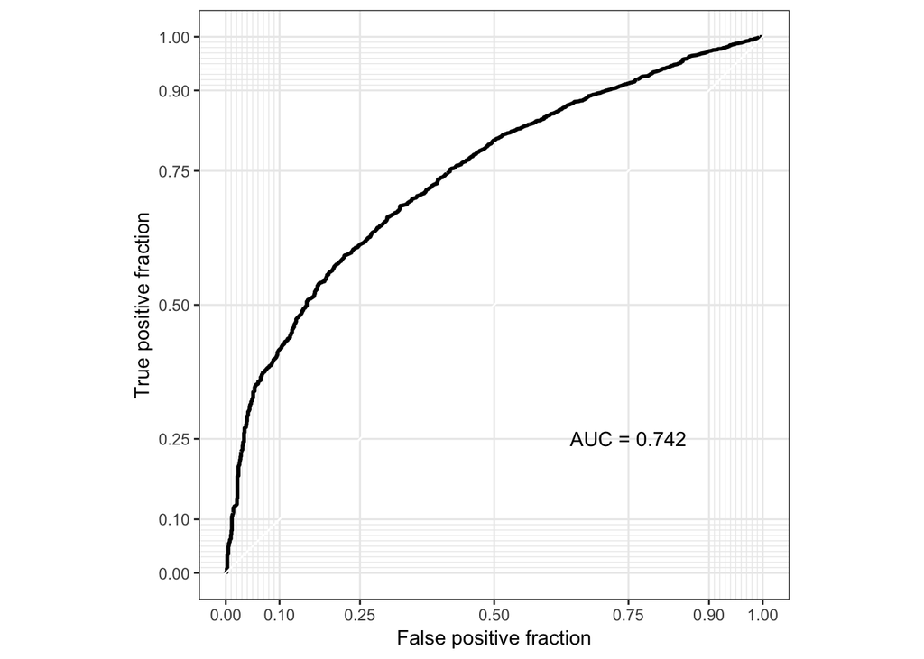

```r
library(plotROC)
rocdata <- data.frame(D = as.integer(testing$loan_status)-1,
                      M = y_pred_prob,
                      Z = ifelse(testing$loan_status=="0","F","S"))
g <- ggplot(rocdata, aes(m = M, d = D)) +
  geom_roc(n.cuts=0) +
  coord_equal() +
  style_roc()
g + annotate("text", x=0.75, y=0.25, label=paste("AUC =", round((calc_auc(g))$AUC, 4)))
```

Regularized logistic regression did very little to improve the model.

# 3 3 Other classification models in caret

```r
ctrl <- trainControl(method = "none")

set.seed(100)
rforest <- train(loan_status ~ ., data = training,
               method = "rf",
               ntree = 1000,
               trControl = ctrl,
               tuneGrid = data.frame(mtry = 6))
rforest
```

```
## Random Forest
##
## 30363 samples
##    18 predictor
##     2 classes: 'F', 'S'
##
## No pre-processing
## Resampling: None
```

```r
y_pred_prob = predict(rforest, testing, type="prob")[,2]
y_pred = as.factor(ifelse( y_pred_prob > .5, 1, 0))
confusionMatrix( y_pred, testing$loan_status )
```

```
## Confusion Matrix and Statistics
##
##           Reference
## Prediction    0    1
##          0  487  126
##          1  574 6403
##
##                Accuracy : 0.9078
##                  95% CI : (0.901, 0.9142)
##     No Information Rate : 0.8602
##     P-Value [Acc > NIR] : < 2.2e-16
##
##                   Kappa : 0.5341
##  Mcnemar's Test P-Value : < 2.2e-16
##
##             Sensitivity : 0.45900
##             Specificity : 0.98070
##          Pos Pred Value : 0.79445
##          Neg Pred Value : 0.91773
##              Prevalence : 0.13979
##          Detection Rate : 0.06416
##    Detection Prevalence : 0.08076
##       Balanced Accuracy : 0.71985
##
##        'Positive' Class : 0
##
```

The random forest model is clobbering logistic regression for this data. Here is the ROC curve:

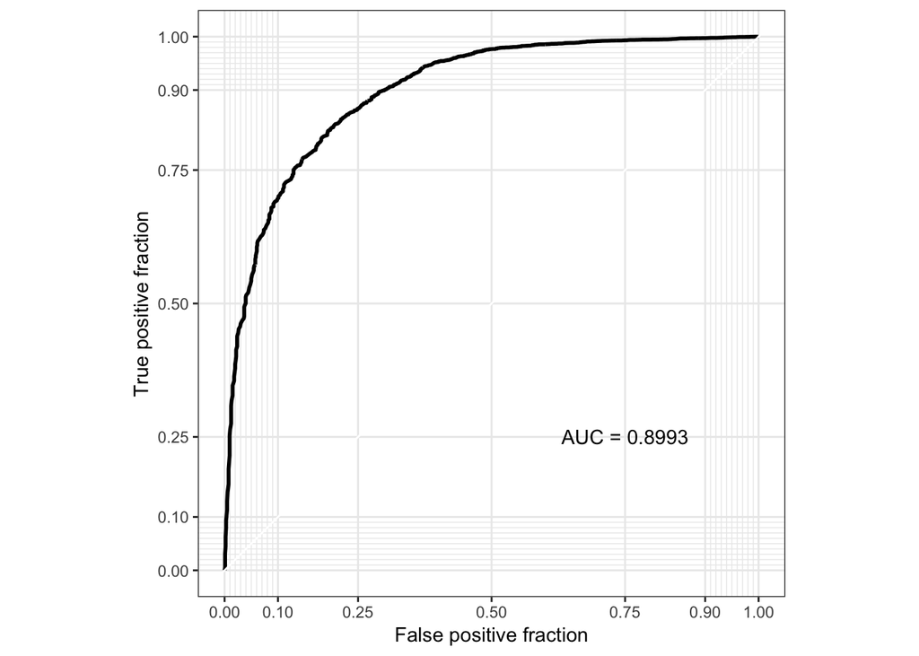

```r
library(plotROC)
rocdata <- data.frame(D = as.integer(testing$loan_status)-1,
                      M = y_pred_prob,
                      Z = ifelse(testing$loan_status=="0","F","S"))
g <- ggplot(rocdata, aes(m = M, d = D)) +
  geom_roc(n.cuts=0) +
  coord_equal() +
  style_roc()
g + annotate("text", x=0.75, y=0.25, label=paste("AUC =", round((calc_auc(g))$AUC, 4)))
```